# 個人勢Vtuberデータセットの解析

## ショート動画をどのくらい上げているかヒストグラムを書いてみる

```r
data_result2 %>%
  filter(sum_short > 0) %>%
  ggplot(
    aes(
      x = sum_short
    )
  ) +
  geom_histogram() +
  xlim(0,1000)
```

## ショートを上げている人限定で相関行列を作る

```r
data_short <-
  data_result2 %>%
  filter(between(sum_short,1,1000))

c<-
  data_short %>%
  select(-title) %>%
  cor()

p<-
  data_short %>%
  select(-title) %>%
  cor.mtest()

round(c,2)　#「c」の中の数値を小数点以下3桁で四捨五入する
corrplot(c, tl.col="black",tl.cex=1.0,tl.srt=45,p.mat=p[[1]],insig="blank",sig.level=0.05)
#corrplot(c, type="upper")
```

### 考察

- short投稿者は配信頻度が低い -> short制作に時間を費やすため？
- shortの質が良いと、配信頻度が低くても配信一回あたりの総来場者が増えるので、  
  トータルでは配信に来る人が多くなる

## 同程度の配信頻度の人がShort動画を作るとどのくらい伸びる？

## 配信頻度を見てみる

```r
data_short %>%
  ggplot(
    aes(
      x = count_live
    )
  ) +
  geom_histogram()
```

### ここから先はサンプル数不足になりそうなので未着手

## 動画再考

### 動画をどのくらい上げているかヒストグラムを書いてみる

```r
data_result2 %>%
  filter(sum_movie > 0) %>%
  ggplot(
    aes(
      x = sum_movie
    )
  ) +
  geom_histogram() +
  xlim(0,8000)
```

### 動画を上げている人限定で相関行列を作る

```r
data_movie <-
  data_result2 %>%
  filter(between(sum_movie,1,8000))

c<-
  data_movie %>%
  select(-title) %>%
  cor()

p<-
  data_movie %>%
  select(-title) %>%
  cor.mtest()

round(c,2)　#「c」の中の数値を小数点以下3桁で四捨五入する
corrplot(c, tl.col="black",tl.cex=1.0,tl.srt=45,p.mat=p[[1]],insig="blank",sig.level=0.05)
#corrplot(c, type="upper")
```

## 統計情報の確認

```r
summary(data_result)
```

## 登録者を絞って見てみる

```r
data_result3 <-
  data_result %>% filter(between(subscriberCount, 100, 1000))
```

## 相関係数の一覧

```r
c<-
  data_result3 %>%
  select(-title) %>%
  cor(use="pairwise.complete.obs")

p<-
  data_result3 %>%
  select(-title) %>%
  cor.mtest(use="pairwise.complete.obs")

round(c,2)　#「c」の中の数値を小数点以下3桁で四捨五入する
corrplot(c, tl.col="black",tl.cex=1.0,tl.srt=45,p.mat=p[[1]],insig="blank",sig.level=0.01)
```

## 重回帰分析してみる

```r
reg = lm(subscriberCount ~ sum_movie + sum_live + sum_short, data_result2)
step(reg)
```

## 多重共線性(VIF>10かどうかで判別)

```r
vif(model)
```

## Q-Qプロット

```r
model = lm(formula = subscriberCount ~ count_live+ mean_short, data = data_result2)

model %>%
  augment() %>%
  mutate(z_res = (.resid - mean(.resid)) / sd(.resid)) %>%
  ggplot(aes(sample = z_res)) +
  geom_abline(a = 0, b = 1, linetype = 2, color = "red") +
  geom_qq()
```

# 対数分布で分析

## 対数のチャンネル登録者

```r
data_result %>%
  ggplot(
    aes(
      x = log(subscriberCount)
    )
  ) +
  geom_histogram()
```

## 1動画あたり再生数の対数ヒストグラム

```r
data_result %>%
  ggplot(
    aes(
      x = log(mean_movie)
    )
  ) +
  geom_histogram()
```

## 対数同士の散布図

```r
data_result %>%
  ggplot(
    aes(
      x = log(mean_short),
      y = log(subscriberCount)
    )
  ) +
  geom_point()
```

## データフレームを対数変換

| subscriberCount | count_movie | mean_movie | count_live | mean_live | count_short | mean_short |
| --- | --- | --- | --- | --- | --- | --- |
| 2.328380 | 0 | NA | 9 | 1.455691 | 0 | NA |
| 3.193125 | 9 | 2.655672 | 10 | 1.990339 | 0 | NA |
| 4.037426 | 5 | 3.065654 | 17 | 2.740641 | 0 | NA |
| 4.152288 | 14 | 3.491422 | 0 | NA | 4 | 3.174569 |
| 2.133539 | 7 | 2.171099 | 6 | 1.792392 | 0 | NA |
| 2.550228 | 16 | 3.017451 | 0 | NA | 15 | 2.006323 |
| 2.376577 | 0 | NA | 31 | 1.632163 | 0 | NA |
| 2.334454 | 0 | NA | 31 | 2.115557 | 0 | NA |
| 2.068186 | 1 | 3.563362 | 18 | 1.903994 | 0 | NA |
| 2.240549 | 7 | 2.572872 | 20 | 1.606381 | 9 | 2.637934 |

[output cut: 149 more lines]

## 相関行列を書く

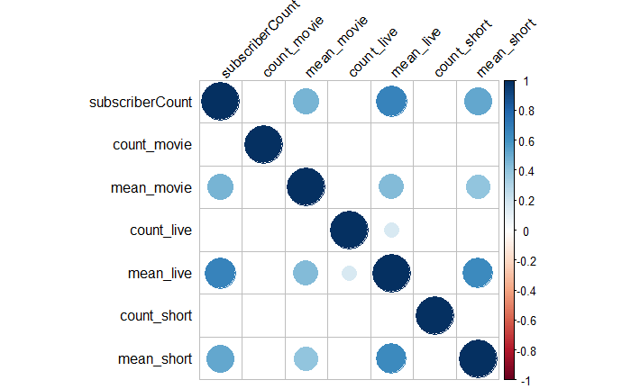

# 偏相関係数

## live と movie

```r
pcor(data_log %>% select(subscriberCount, mean_live, mean_movie) %>% drop_na)
```

```
$estimate
                subscriberCount mean_live mean_movie
subscriberCount       1.0000000 0.5694650  0.1481921
mean_live             0.5694650 1.0000000  0.2718651
mean_movie            0.1481921 0.2718651  1.0000000

$p.value
                subscriberCount    mean_live mean_movie
subscriberCount    0.000000e+00 2.050886e-06 0.25847752
mean_live          2.050886e-06 0.000000e+00 0.03561338
mean_movie         2.584775e-01 3.561338e-02 0.00000000

$statistic
                subscriberCount mean_live mean_movie
subscriberCount        0.000000  5.275954   1.141198
mean_live              5.275954  0.000000   2.151498
mean_movie             1.141198  2.151498   0.000000

$n
[1] 61

$gp
[1] 1

$method
[1] "pearson"
```

## live と short

```r
pcor(data_log %>% select(subscriberCount, mean_live, mean_short) %>% drop_na)
```

## movie と short

```r
pcor(data_log %>% select(subscriberCount, mean_movie, mean_short) %>% drop_na)
```

### 考察

- live, movie, shortはsubscriberCountを無視してもそれなりに相関があるっぽい

# 因果探索(LiNGAM)

```r
# LiNGAMモデルの推定用関数定義
est_lingam <- function(X){

  model <-
    X %>%
    lingam(verbose = F)

  arrow_amt <-
    model %>%
    as("amat") %>%
    as.matrix()

  colnames(arrow_amt) <- names(X)
  rownames(arrow_amt) <- names(X)

  return(arrow_amt)
}
```

## 二項因果

### mean_movie

```r
data
```

```
Adjacency Matrix 'amat' (2 x 2) of type ‘pag’:
                subscriberCount mean_movie
subscriberCount               .          1
mean_movie                    .          .
```

### mean_live

```r
data
```

```
Adjacency Matrix 'amat' (2 x 2) of type ‘pag’:
                subscriberCount mean_live
subscriberCount               .         .
mean_live                     1         .
```

### mean_short

```r
data
```

```
Adjacency Matrix 'amat' (2 x 2) of type ‘pag’:
                subscriberCount mean_short
subscriberCount               .       0.49
mean_short                    .          .
```

### count_movie

```r
data
```

```
Adjacency Matrix 'amat' (2 x 2) of type ‘pag’:
                subscriberCount count_movie
subscriberCount               .           .
count_movie                   .           .
```

### count_live

```r
data
```

```
Adjacency Matrix 'amat' (2 x 2) of type ‘pag’:
                subscriberCount count_live
subscriberCount               .          .
count_live                    .          .
```

### count_short

```r
data
```

```
Adjacency Matrix 'amat' (2 x 2) of type ‘pag’:
                subscriberCount count_short
subscriberCount               .           .
count_short                   .           .
```

### count_movie

```r
data
```

```
Adjacency Matrix 'amat' (2 x 2) of type ‘pag’:
                subscriberCount count_movie
subscriberCount               .           .
count_movie                   .           .
```

### 配信をたくさんすればうまくなる？

```r
data
```

```
Adjacency Matrix 'amat' (2 x 2) of type ‘pag’:
           count_live mean_live
count_live          .         .
mean_live           .         .
```

### liveとshortの因果関係

```r
data
```

```
Adjacency Matrix 'amat' (2 x 2) of type ‘pag’:
           mean_live mean_short
mean_live          .          .
mean_short         .          .
```

### liveとmovieの因果関係

```r
data
```

```
Adjacency Matrix 'amat' (2 x 2) of type ‘pag’:
           mean_live mean_movie
mean_live          .       0.54
mean_movie      0.46          .
```

## 3項

### media

```r
data
```

```
Adjacency Matrix 'amat' (3 x 3) of type ‘pag’:
                subscriberCount count_movie mean_movie
subscriberCount               .           .       0.54
count_movie                   .           .          .
mean_movie                 0.46           .          .
```

### live

```r
data
```

```
Adjacency Matrix 'amat' (3 x 3) of type ‘pag’:
                subscriberCount count_live mean_live
subscriberCount               .          .      0.39
count_live                    .          .         .
mean_live                  0.61          .         .
```

### short

```r
data
```

```
Adjacency Matrix 'amat' (3 x 3) of type ‘pag’:
                subscriberCount count_short mean_short
subscriberCount               .           .          1
count_short                   .           .          .
mean_short                    .           .          .
```

### liveとmovie

```r
data
```

```
Adjacency Matrix 'amat' (3 x 3) of type ‘pag’:
                subscriberCount mean_live mean_movie
subscriberCount               .      0.53          .
mean_live                  0.47         .          .
mean_movie                    .         .          .
```

## ごちゃまぜ

```r
data
```

```
Adjacency Matrix 'amat' (4 x 4) of type ‘pag’:
                subscriberCount mean_live mean_short mean_movie
subscriberCount               .         .          .          .
mean_live                     .         .          .          .
mean_short                    .         .          .          .
mean_movie                    .         .          .          .
```

# 重回帰分析

```r
reg %>%  summary
```

[output not shown]

```r
summary(
  lm(formula = subscriberCount ~ mean_live, data = data_reg)
)
```

# SEM

## 相関関係にある指標

subscriberCount <-> mean_live, mean_movie, mean_short

## mean同士

```r
data12 <- '
mean_live  ~ subscriberCount
mean_movie ~ subscriberCount
mean_short ~ subscriberCount
subscriberCount ~~ 1*subscriberCount
'
model12 <- sem(data12, fixed.x = FALSE, data= data_log %>% drop_na)


data09 <- '
subscriberCount ~ mean_live + mean_movie + mean_short
mean_live ~~ 1*mean_live

'
model09 <- sem(data09, fixed.x = FALSE, data= data_log %>% drop_na)


data14 <- '
subscriberCount ~ mean_movie + mean_short
mean_live    ~ subscriberCount
mean_movie ~~ 1*mean_movie
'
model14 <- sem(data14, fixed.x = FALSE, data= data_log %>% drop_na)


data10 <- '
subscriberCount ~ mean_live + mean_short
mean_movie    ~ subscriberCount
mean_live ~~ 1*mean_live
'
model10 <- sem(data10, fixed.x = FALSE, data= data_log %>% drop_na)


data13 <- '
subscriberCount ~ mean_live + mean_movie
mean_short    ~ subscriberCount
mean_live ~~ 1*mean_live
'
model13 <- sem(data13, fixed.x = FALSE, data= data_log %>% drop_na)

data15 <- '
subscriberCount ~ mean_live
mean_movie    ~ subscriberCount
mean_short    ~ subscriberCount
mean_live ~~ 1*mean_live
'
model15 <- sem(data15, fixed.x = FALSE, data= data_log %>% drop_na)

data16 <- '
subscriberCount ~ mean_movie
mean_live     ~ subscriberCount
mean_short    ~ subscriberCount
mean_movie ~~ 1*mean_movie
'
model16 <- sem(data16, fixed.x = FALSE, data= data_log %>% drop_na)
data17 <- '
subscriberCount ~ mean_short
mean_live     ~ subscriberCount
mean_movie    ~ subscriberCount
mean_short ~~ 1*mean_short
'
model17 <- sem(data17, fixed.x = FALSE, data= data_log %>% drop_na)
```

```r
print("model12")
```

```
[1] "model12"
```

```r
fitmeasures(model12, c("chisq", "df", "pvalue","gfi", "agfi", "nfi", "cfi", "rmsea", "aic"))
```

```
  chisq      df  pvalue     gfi    agfi     nfi     cfi   rmsea     aic
 10.625   1.000   0.001   0.811  -0.887   0.697   0.669   0.620 344.558
```

```r
print("model9")
```

```
[1] "model9"
```

```r
fitmeasures(model09, c("chisq", "df", "pvalue","gfi", "agfi", "nfi", "cfi", "rmsea", "aic"))
```

```
  chisq      df  pvalue     gfi    agfi     nfi     cfi   rmsea     aic
 19.743   3.000   0.000   0.736   0.120   0.349   0.339   0.472 349.676
```

```r
print("model14")
```

```
[1] "model14"
```

```r
fitmeasures(model14, c("chisq", "df", "pvalue","gfi", "agfi", "nfi", "cfi", "rmsea", "aic"))
```

```
  chisq      df  pvalue     gfi    agfi     nfi     cfi   rmsea     aic
 21.895   4.000   0.000   0.695   0.238   0.376   0.384   0.423 349.828
```

```r
print("model10")
```

```
[1] "model10"
```

```r
fitmeasures(model10, c("chisq", "df", "pvalue","gfi", "agfi", "nfi", "cfi", "rmsea", "aic"))
```

```
  chisq      df  pvalue     gfi    agfi     nfi     cfi   rmsea     aic
 23.801   4.000   0.000   0.692   0.229   0.321   0.319   0.445 351.734
```

```r
print("model13")
```

```
[1] "model13"
```

```r
fitmeasures(model13, c("chisq", "df", "pvalue","gfi", "agfi", "nfi", "cfi", "rmsea", "aic"))
```

```
  chisq      df  pvalue     gfi    agfi     nfi     cfi   rmsea     aic
 16.482   4.000   0.002   0.750   0.374   0.530   0.571   0.353 344.415
```

```r
print("model15")
```

```
[1] "model15"
```

```r
fitmeasures(model15, c("chisq", "df", "pvalue","gfi", "agfi", "nfi", "cfi", "rmsea", "aic"))
```

```
  chisq      df  pvalue     gfi    agfi     nfi     cfi   rmsea     aic
 11.602   3.000   0.009   0.821   0.405   0.669   0.704   0.339 341.536
```

```r
print("model16")
```

```
[1] "model16"
```

```r
fitmeasures(model16, c("chisq", "df", "pvalue","gfi", "agfi", "nfi", "cfi", "rmsea", "aic"))
```

```
  chisq      df  pvalue     gfi    agfi     nfi     cfi   rmsea     aic
 12.473   3.000   0.006   0.780   0.266   0.644   0.674   0.355 342.406
```

```r
print("model17")
```

```
[1] "model17"
```

```r
fitmeasures(model17, c("chisq", "df", "pvalue","gfi", "agfi", "nfi", "cfi", "rmsea", "aic"))
```

```
  chisq      df  pvalue     gfi    agfi     nfi     cfi   rmsea     aic
 19.577   3.000   0.000   0.722   0.074   0.442   0.430   0.470 349.510
```

```r
data22 <- '
subscriberCount ~ mean_live
mean_movie    ~ subscriberCount
mean_short    ~ subscriberCount
mean_live ~~ 1*mean_live
'
model22 <- sem(data22, fixed.x = FALSE, data= data_log %>% drop_na)

data23 <- '
subscriberCount ~ mean_live
mean_movie    ~ mean_live
mean_short    ~ mean_live + subscriberCount
mean_live    ~~ 1*mean_live
'
model23 <- sem(data23, fixed.x = FALSE, data= data_log %>% drop_na)
```

```r
print("model22")
```

```
[1] "model22"
```

```r
fitmeasures(model22, c("chisq", "df", "pvalue","gfi", "agfi", "nfi", "cfi", "rmsea", "aic"))
```

```
  chisq      df  pvalue     gfi    agfi     nfi     cfi   rmsea     aic
 11.602   3.000   0.009   0.821   0.405   0.669   0.704   0.339 341.536
```

```r
print("model23")
```

```
[1] "model23"
```

```r
fitmeasures(model23, c("chisq", "df", "pvalue","gfi", "agfi", "nfi", "cfi", "rmsea", "aic"))
```

```
  chisq      df  pvalue     gfi    agfi     nfi     cfi   rmsea     aic
  2.799   2.000   0.247   0.944   0.720   0.920   0.973   0.126 334.732
```

```r
summary(model23)
```

```r
data24 <- '
subscriberCount ~ mean_live + count_live
mean_movie    ~ subscriberCount
mean_short    ~ subscriberCount
mean_live    ~~ 1*mean_live
'
model24 <- sem(data24, fixed.x = FALSE, data= data_log %>% drop_na)

data30 <- '
subscriberCount ~ mean_live + count_live
mean_movie    ~ subscriberCount + count_live + mean_live
mean_short    ~ subscriberCount
mean_live    ~~ 1*mean_live
'
model30 <- sem(data30, fixed.x = FALSE, data= data_log %>% drop_na)

data29 <- '
subscriberCount ~ mean_live + count_live
mean_movie    ~ subscriberCount
mean_short    ~ subscriberCount + count_live + mean_live
count_live     ~~ 1*count_live
'
model29 <- sem(data29, fixed.x = FALSE, data= data_log %>% drop_na)

data31 <- '
subscriberCount ~ mean_live + count_live
mean_movie    ~ subscriberCount
mean_short    ~ mean_live + count_live
count_live     ~~ 1*count_live
'
model31 <- sem(data31, fixed.x = FALSE, data= data_log %>% drop_na)

data33 <- '
subscriberCount ~ mean_live + count_live
mean_movie    ~ count_live
mean_short    ~ mean_live + count_live
count_live     ~~ 1*count_live
'
model33 <- sem(data33, fixed.x = FALSE, data= data_log %>% drop_na)
```

```r
print("model24")
```

```
[1] "model24"
```

```r
fitmeasures(model24, c("chisq", "df", "pvalue","gfi", "agfi", "nfi", "cfi", "rmsea", "aic"))
```

```
  chisq      df  pvalue     gfi    agfi     nfi     cfi   rmsea     aic
 16.632   6.000   0.011   0.797   0.492   0.609   0.673   0.266 413.116
```

```r
print("model30")
```

```
[1] "model30"
```

```r
fitmeasures(model30, c("chisq", "df", "pvalue","gfi", "agfi", "nfi", "cfi", "rmsea", "aic"))
```

```
  chisq      df  pvalue     gfi    agfi     nfi     cfi   rmsea     aic
 16.414   4.000   0.003   0.798   0.243   0.614   0.619   0.352 416.898
```

```r
print("model29")
```

```
[1] "model29"
```

```r
fitmeasures(model29, c("chisq", "df", "pvalue","gfi", "agfi", "nfi", "cfi", "rmsea", "aic"))
```

```
  chisq      df  pvalue     gfi    agfi     nfi     cfi   rmsea     aic
  3.814   4.000   0.432   0.941   0.778   0.910   1.000   0.000 404.297
```

```r
print("model31")
```

```
[1] "model31"
```

```r
fitmeasures(model31, c("chisq", "df", "pvalue","gfi", "agfi", "nfi", "cfi", "rmsea", "aic"))
```

```
  chisq      df  pvalue     gfi    agfi     nfi     cfi   rmsea     aic
  5.420   5.000   0.367   0.919   0.756   0.873   0.987   0.058 403.903
```

```r
print("model33")
```

```
[1] "model33"
```

```r
fitmeasures(model33, c("chisq", "df", "pvalue","gfi", "agfi", "nfi", "cfi", "rmsea", "aic"))
```

```
  chisq      df  pvalue     gfi    agfi     nfi     cfi   rmsea     aic
  3.528   3.000   0.317   0.950   0.750   0.917   0.984   0.084 406.012
```

```r
summary(model33)
```

# SEM(movieだけ)

```r
data_sem_movie = data_log %>% filter(count_movie>0)

data34 <- '
mean_live  ~ subscriberCount
mean_movie ~ subscriberCount
subscriberCount ~~ 1*subscriberCount
'
model34 <- sem(data34, fixed.x = FALSE, data= data_sem_movie)

data35 <- '
subscriberCount ~ mean_live + mean_movie
mean_live ~~ 1*mean_live
'
model35 <- sem(data35, fixed.x = FALSE, data= data_sem_movie)

data36 <- '
subscriberCount ~ mean_live
mean_movie    ~ subscriberCount
mean_live ~~ 1*mean_live
'
model36 <- sem(data36, fixed.x = FALSE, data= data_sem_movie)

data37 <- '
subscriberCount ~ mean_movie
mean_live     ~ subscriberCount
mean_movie ~~ 1*mean_movie
'
model37 <- sem(data37, fixed.x = FALSE, data= data_sem_movie)

data38 <- '
subscriberCount ~ mean_live
mean_movie    ~ mean_live
mean_live  ~~ 1*mean_live
'
model38 <- sem(data38, fixed.x = FALSE, data= data_sem_movie)
```

```r
print("model34")
```

```
[1] "model34"
```

```r
fitmeasures(model34, c("chisq", "df", "pvalue","gfi", "agfi", "nfi", "cfi", "rmsea", "aic"))
```

```
  chisq      df  pvalue     gfi    agfi     nfi     cfi   rmsea     aic
 22.020   1.000   0.000   0.738  -0.569   0.467   0.451   0.725 421.533
```

```r
print("model35")
```

```
[1] "model35"
```

```r
fitmeasures(model35, c("chisq", "df", "pvalue","gfi", "agfi", "nfi", "cfi", "rmsea", "aic"))
```

```
  chisq      df  pvalue     gfi    agfi     nfi     cfi   rmsea     aic
 23.492   2.000   0.000   0.722   0.167   0.431   0.439   0.518 421.005
```

```r
print("model36")
```

```
[1] "model36"
```

```r
fitmeasures(model36, c("chisq", "df", "pvalue","gfi", "agfi", "nfi", "cfi", "rmsea", "aic"))
```

```
  chisq      df  pvalue     gfi    agfi     nfi     cfi   rmsea     aic
 12.738   2.000   0.002   0.831   0.494   0.692   0.720   0.366 410.251
```

```r
print("model37")
```

```
[1] "model37"
```

```r
fitmeasures(model37, c("chisq", "df", "pvalue","gfi", "agfi", "nfi", "cfi", "rmsea", "aic"))
```

```
  chisq      df  pvalue     gfi    agfi     nfi     cfi   rmsea     aic
 19.743   2.000   0.000   0.757   0.272   0.522   0.537   0.471 417.256
```

```r
print("model38")
```

```
[1] "model38"
```

```r
fitmeasures(model38, c("chisq", "df", "pvalue","gfi", "agfi", "nfi", "cfi", "rmsea", "aic"))
```

```
  chisq      df  pvalue     gfi    agfi     nfi     cfi   rmsea     aic
  8.624   1.000   0.003   0.876   0.257   0.791   0.801   0.437 408.137
```

# SEM(shortだけ)

```r
data_sem_short = data_log %>% filter(count_short>0)

data34 <- '
mean_live  ~ subscriberCount
mean_short ~ subscriberCount
subscriberCount ~~ 1*subscriberCount
'
model34 <- sem(data34, fixed.x = FALSE, data= data_sem_short)

data38 <- '
subscriberCount ~ mean_live
mean_short    ~ mean_live
mean_live  ~~ 1*mean_live
'
model38 <- sem(data38, fixed.x = FALSE, data= data_sem_short)

data42 <- '
subscriberCount ~ mean_live + mean_short
mean_live  ~~ 1*mean_live
'
model42 <- sem(data42, fixed.x = FALSE, data= data_sem_short)

data43 <- '
mean_short ~ mean_live + subscriberCount
mean_live  ~~ 1*mean_live
'
model43 <- sem(data43, fixed.x = FALSE, data= data_sem_short)

data44 <- '
mean_live ~ subscriberCount + mean_short
mean_short  ~~ 1*mean_short
'
model44 <- sem(data44, fixed.x = FALSE, data= data_sem_short)

data35 <- '
subscriberCount ~ mean_live + mean_short
mean_live ~~ 1*mean_live
'
model35 <- sem(data35, fixed.x = FALSE, data= data_sem_short)

data36 <- '
subscriberCount ~ mean_live
mean_short    ~ subscriberCount
mean_live ~~ 1*mean_live
'
model36 <- sem(data36, fixed.x = FALSE, data= data_sem_short)

data37 <- '
subscriberCount ~ mean_short
mean_live     ~ subscriberCount
mean_short ~~ 1*mean_short
'
model37 <- sem(data37, fixed.x = FALSE, data= data_sem_short)

data39 <- '
subscriberCount ~ mean_live
mean_live     ~ mean_short
mean_short   ~~ 1*mean_short
'
model39 <- sem(data39, fixed.x = FALSE, data= data_sem_short)

data40 <- '
subscriberCount ~ mean_short
mean_short    ~ mean_live
mean_live    ~~ 1*mean_live
'
model40 <- sem(data40, fixed.x = FALSE, data= data_sem_short)

data41 <- '
subscriberCount ~ mean_live
mean_short    ~ mean_live
mean_live  ~~ 1*mean_live
'
model41 <- sem(data41, fixed.x = FALSE, data= data_sem_short)
```

```r
print("model34")
fitmeasures(model34, c("chisq", "df", "pvalue","gfi", "agfi", "nfi", "cfi", "rmsea", "aic"))

print("model38")
fitmeasures(model38, c("chisq", "df", "pvalue","gfi", "agfi", "nfi", "cfi", "rmsea", "aic"))

print("model42")
fitmeasures(model42, c("chisq", "df", "pvalue","gfi", "agfi", "nfi", "cfi", "rmsea", "aic"))

print("model43")
fitmeasures(model43, c("chisq", "df", "pvalue","gfi", "agfi", "nfi", "cfi", "rmsea", "aic"))

print("model44")
fitmeasures(model44, c("chisq", "df", "pvalue","gfi", "agfi", "nfi", "cfi", "rmsea", "aic"))

print("model35")
fitmeasures(model35, c("chisq", "df", "pvalue","gfi", "agfi", "nfi", "cfi", "rmsea", "aic"))

print("model36")
fitmeasures(model36, c("chisq", "df", "pvalue","gfi", "agfi", "nfi", "cfi", "rmsea", "aic"))

print("model37")
fitmeasures(model37, c("chisq", "df", "pvalue","gfi", "agfi", "nfi", "cfi", "rmsea", "aic"))

print("model39")
fitmeasures(model39, c("chisq", "df", "pvalue","gfi", "agfi", "nfi", "cfi", "rmsea", "aic"))

print("model40")
fitmeasures(model40, c("chisq", "df", "pvalue","gfi", "agfi", "nfi", "cfi", "rmsea", "aic"))

print("model41")
fitmeasures(model41, c("chisq", "df", "pvalue","gfi", "agfi", "nfi", "cfi", "rmsea", "aic"))
```

```r
summary(model41)
```

[output not shown]

mean_short, mean_live, count_liveを混ぜたモデル

```r
data45 <- '
subscriberCount ~ mean_live + count_live + mean_short
mean_live       ~~ 1*mean_live
'
model45 <- sem(data45, fixed.x = FALSE, data= data_sem_short)

data46 <- '
mean_live       ~ count_live
subscriberCount ~ mean_live + mean_short
count_live       ~~ 1*count_live
'
model46 <- sem(data46, fixed.x = FALSE, data= data_sem_short)

data47 <- '
mean_live       ~ count_live
subscriberCount ~ mean_live
mean_short      ~ mean_live
count_live       ~~ 1*count_live
'
model47 <- sem(data47, fixed.x = FALSE, data= data_sem_short)

data48 <- '
mean_live       ~ count_live
subscriberCount ~ mean_live
mean_short      ~ subscriberCount
count_live       ~~ 1*count_live
'
model48 <- sem(data48, fixed.x = FALSE, data= data_sem_short)

data49 <- '
subscriberCount  ~ mean_live + count_live
mean_short       ~ mean_live
mean_live       ~~ 1*mean_live
'
model49 <- sem(data49, fixed.x = FALSE, data= data_sem_short)
```

```r
print("model45")
```

```
[1] "model45"
```

```r
fitmeasures(model45, c("chisq", "df", "pvalue","gfi", "agfi", "nfi", "cfi", "rmsea", "aic"))
```

```
  chisq      df  pvalue     gfi    agfi     nfi     cfi   rmsea     aic
 21.178   3.000   0.000   0.704   0.015   0.392   0.391   0.502 318.157
```

```r
print("model46")
```

```
[1] "model46"
```

```r
fitmeasures(model46, c("chisq", "df", "pvalue","gfi", "agfi", "nfi", "cfi", "rmsea", "aic"))
```

```
  chisq      df  pvalue     gfi    agfi     nfi     cfi   rmsea     aic
 25.086   4.000   0.000   0.728   0.319   0.363   0.368   0.469 320.065
```

```r
print("model47")
```

```
[1] "model47"
```

```r
fitmeasures(model47, c("chisq", "df", "pvalue","gfi", "agfi", "nfi", "cfi", "rmsea", "aic"))
```

```
  chisq      df  pvalue     gfi    agfi     nfi     cfi   rmsea     aic
  9.674   3.000   0.022   0.871   0.569   0.754   0.800   0.304 306.653
```

```r
print("model48")
```

```
[1] "model48"
```

```r
fitmeasures(model48, c("chisq", "df", "pvalue","gfi", "agfi", "nfi", "cfi", "rmsea", "aic"))
```

```
  chisq      df  pvalue     gfi    agfi     nfi     cfi   rmsea     aic
 16.807   4.000   0.002   0.799   0.499   0.573   0.616   0.365 311.786
```

```r
print("model49")
```

```
[1] "model49"
```

```r
fitmeasures(model49, c("chisq", "df", "pvalue","gfi", "agfi", "nfi", "cfi", "rmsea", "aic"))
```

```
  chisq      df  pvalue     gfi    agfi     nfi     cfi   rmsea     aic
 10.295   3.000   0.016   0.844   0.481   0.739   0.781   0.318 307.274
```

```r
summary(model47)
```

```
lavaan 0.6.17 ended normally after 8 iterations

  Estimator                                         ML
  Optimization method                           NLMINB
  Number of model parameters                         7

                                                  Used       Total
  Number of observations                            24          33

Model Test User Model:

  Test statistic                                 9.674
  Degrees of freedom                                 3
  P-value (Chi-square)                           0.022

Parameter Estimates:

  Standard errors                             Standard
  Information                                 Expected
  Information saturated (h1) model          Structured

Regressions:
                    Estimate  Std.Err  z-value  P(>|z|)
  mean_live ~
    count_live         0.217    0.267    0.811    0.417
  subscriberCount ~
    mean_live          0.807    0.183    4.411    0.000
  mean_short ~
    mean_live          0.827    0.177    4.667    0.000

Covariances:
                     Estimate  Std.Err  z-value  P(>|z|)
 .subscriberCount ~~
   .mean_short          0.265    0.285    0.932    0.351

Variances:
                   Estimate  Std.Err  z-value  P(>|z|)
    count_live        1.000
   .mean_live         1.714    0.495    3.464    0.001
   .subscriberCont    1.414    0.408    3.464    0.001
   .mean_short        1.328    0.383    3.464    0.001
```